# Final Project

2025-05-18

# Research Question

Chile’s rapid economic growth from the 1980s through the early 2000s is often referred to as one of Latin America’s economic miracles. Chile is currently a high-income country with a GNI per capita of ($15,800 current USD), higher than Mexico ($11,980) and China ($13,390) as of 2023 (World Bank, 2023). Over 60% of people lived below the poverty line in the late 1980s, but by 2022, that number fell to 5% (World Bank, 2024). Despite its economic success, Chile remains deeply unequal, a fact exposed by mass protests in 2019 after a four-percent metro fare hike (Edwards, 2023). On October 25, 2019, around 1.2 million Chileans gathered in Santiago to protest (Vergara & Luna, 2019). Though the increase was just thirty pesos (about four U.S. cents), it sparked the largest protest in Chile’s democratic history and raised a pressing question: how did a booming, high-income nation celebrated as a successful economic model, face such widespread intense public discontent over a relatively minor policy change?

Mass mobilization can reflect strong civic engagement but may also signal a disconnect between citizens and the state, especially during periods of economic growth. We use 2023 Latinobarómetro data, a regional survey conducted across 18 Latin American countries, which includes a nationally representative sample of about 1,200 Chileans and covers political, economic, and social topics.

# Data Cleaning

To examine protest participation, we identified survey questions related to democracy, trust, freedom, and economic outlook. Since the 2019 protests were driven by frustration over inequality, high living costs, and perceived corruption among elites, we hypothesized that these factors would be key to understanding who is more likely to protest. Because these questions use different response scales, we standardized them and generated a score between 0 and 1 for each participant in each category. An example question might include: “In general, would you say you are very satisfied, quite satisfied, not very satisfied, or not at all satisfied with the working of democracy in Chile?”

While the survey does not include a direct question about protest attendance, we created a proxy binary variable to reflect protest participation. This was based on responses to protest-related questions such as “Please tell me whether you strongly agree, agree, disagree, or strongly disagree with the following statement: Protests.” We used responses from eight such questions to construct a protest engagement score, which we then converted into a binary outcome (1 = likely protester, 0 = unlikely protester) using the median as a threshold.

### Protest Variable

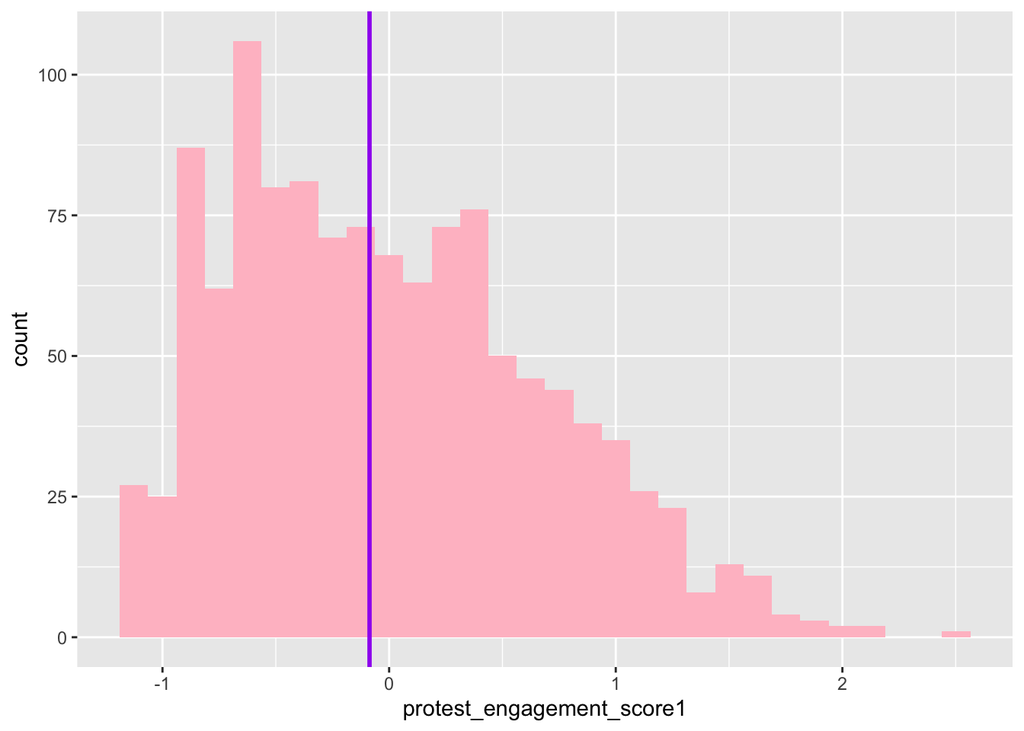

```r
renamed_full <- read_dta("~/Downloads/2023_renamed.dta")
renamed_full <- renamed_full |>
  filter(idenpa == 152) |>
  mutate(across(everything(), ~ as.numeric(as.character(.))))

#Building Protest Variable
predictors <- c(
  "talkoftenpolitics",
  "interestinpolitics",
  "workforcommunity",
  "authdemonst",
  "nonauthdemonst",
  "protestinsocmedia",
  "opinionplatform",
  "protestagree"
)

#Since 'Don't know' and 'No answer' are assigned their own values in the dataset, we recoded them as NA so they do not distort the scale when we standardize our variables.
renamed_full_clean <-renamed_full  |>
  mutate(across(
    all_of(predictors),
    ~ if_else(.x %in% c(8, 97, 98, 99, -5, -4, -3, -1, -2), NA_real_, as.numeric(.x))
  ))

#Standardize
protest_scaled <- scale(renamed_full_clean[, predictors])
protest_scaled_df <- as.data.frame(protest_scaled)

#Reverse the order (higher values = more positive attitudes)
protest_scaled_sd <- protest_scaled_df |>
  mutate(protest_engagement_score1 = -rowMeans(across(all_of(predictors)), na.rm = TRUE))

#Scaling
renamed_full_clean <- renamed_full_clean |>
  mutate(
    protest_engagement_score1 = -rowMeans(scale(across(all_of(predictors))), na.rm = TRUE)
  )

#Look at the distribution of the protest engagement variable as well as the median
renamed_full_clean |>
  ggplot() +
  geom_histogram(aes(x = protest_engagement_score1), fill = "pink") +
  geom_vline(
    xintercept = median(protest_scaled_sd$protest_engagement_score1, na.rm = TRUE),
    color = "purple",
    linewidth = 1
  )
```

```r
threshold <- median(renamed_full_clean$protest_engagement_score1, na.rm = TRUE)

renamed_full_cleann <- renamed_full_clean |>
  mutate(protest_attend = if_else(protest_engagement_score1 > threshold, 1, 0))
```

### Democracy, Trust, Economy, and Freedom Indices

```r
#Choosing the relevant survey questions for each category
democracy_vars <- c(
  "democracypreference", "democracysatisfaction",
  "governedbyfew", "democracybest")

trust_vars <- c(
  "trustinarmedforces", "trustinpolice", "trustinchurch", "trustincongress",
  "trustinnationalgovernment", "trustinjudiciary", "trustinpoliticalparties",
  "trustinelectoralinst", "trustinnatcompanies", "trustintradeunions",
  "trustintelevision", "trustintlcompanies", "trustinbanks", "trustinradio",
  "trustinprintedpress", "trustinsocmedia", "presleadershipapproval",
  "trustinpeople"
)

economic_vars <- c(
  "lifesatisfaction", "countryprogress", "countryproblems",
  "countryeconomicsituation", "countrypast12monthseconsituation",
  "countrynext12monthseconsituation", "familynext12monthseconsituation",
  "incomedistfairness", "economysatisfaction"
)

freedom_vars <- c(
  "freedompoliticalpart", "freedomenv", "freedomprivateproperty",
  "justfairwealthdistf", "equalityofmenwomenf", "chanceswuoriginf",
  "freedomofspeech", "freedomofreligion", "protectionagainstcrimef",
  "socialsecurityf", "freedomchancetogetjob", "publicopinionexpression"
)

#more cleaning
renamed_full_cleannp <- renamed_full_cleann |>
  mutate(across(
    all_of(c(democracy_vars, trust_vars, economic_vars, freedom_vars)),
    ~ if_else(.x %in% c(8, 97, 98, 99, -5, -4, -3, -1, -2), NA_real_, as.numeric(.x))
  ))

renamed_full_scaled <- renamed_full_cleannp %>%
  mutate(
    democracy_score = rowMeans(select(., all_of(democracy_vars)), na.rm = TRUE),
    trust_score     = rowMeans(select(., all_of(trust_vars)), na.rm = TRUE),
    economic_score  = rowMeans(select(., all_of(economic_vars)), na.rm = TRUE),
    freedom_score   = rowMeans(select(., all_of(freedom_vars)), na.rm = TRUE)
  )

renamed_full_cleaner <- renamed_full_scaled  |>
  mutate(
    democracy_new = (democracy_score - min(democracy_score, na.rm = TRUE)) /
                             (max(democracy_score, na.rm = TRUE) - min(democracy_score, na.rm = TRUE)),

    trust_new = (trust_score - min(trust_score, na.rm = TRUE)) /
                         (max(trust_score, na.rm = TRUE) - min(trust_score, na.rm = TRUE)),

    economic_new = (economic_score - min(economic_score, na.rm = TRUE)) /
                            (max(economic_score, na.rm = TRUE) - min(economic_score, na.rm = TRUE)),

    freedom_new = (freedom_score - min(freedom_score, na.rm = TRUE)) /
                           (max(freedom_score, na.rm = TRUE) - min(freedom_score, na.rm = TRUE))
  )
```

### Demographics

Using our contextual knowledge, we filtered out relevant demographic variables in addition to the four categories because there are over 200 variables in the dataset. We included (and cleaned) 9 variables such as age, socio-economic class, religion, devoutness, race, education, and political leaning.

```r
demographics <- c("religion",
  "religiondevout",
  "socioeconclass",
  "incomeenough",
  "race",
  "education",
  "householdheademp",
  "leftrightscale")

renamed_full_cleaner11 <- renamed_full_cleaner |>
  mutate(across(
    all_of(c(demographics)),
    ~ if_else(.x %in% c(8, 97, 98, 99, -5, -4, -3, -1, -2), NA_real_, as.numeric(.x))
  ))

protestData <- renamed_full_cleaner11
```

# Random Forest

Using four thematic categories and nine demographic variables, we built a random forest model to predict protest participation. This method is effective because it combines predictions from multiple decision trees, each trained on different subsets of the data. For example, one tree might weigh views on democracy and age, while another focuses on economic outlook and trust. Each tree casts a “vote,” and the model aggregates these to make a final prediction. By using many trees and varying the input variables, the model avoids overfitting and improves reliability. Random forest also handles both numerical and categorical variables well.

### First Stage

```r
library(ranger)
set.seed(1)

protestData <- protestData |>
  mutate(across(c(protest_attend, religion, religiondevout, socioeconclass, incomeenough, race, education), as.factor))

protestDataClean13vars <- protestData |>
                select(protest_attend, religion, religiondevout, socioeconclass,
                       incomeenough, race, education, age, leftrightscale,
                       democracy_score, trust_score, economic_score, freedom_score) |>
  na.omit() |>
  mutate(across(c(protest_attend, religion, religiondevout, socioeconclass, incomeenough, race, education), as.factor))

#looking at data without NAs just to see which variables are most important
rf_NAs <- ranger(protest_attend ~ . - protest_label -protest_engagement_score1,
             data = protestDataClean13vars,
             importance = "impurity")
rf_NAs
```

```
## Ranger result
##
## Call:
##  ranger(protest_attend ~ . - protest_label - protest_engagement_score1,      data = protestDataClean13vars, importance = "impurity")
##
## Type:                             Classification
## Number of trees:                  500
## Sample size:                      443
## Number of independent variables:  12
## Mtry:                             3
## Target node size:                 1
## Variable importance mode:         impurity
## Splitrule:                        gini
## OOB prediction error:             37.25 %
```

```r
rf_NAs$confusion.matrix
```

```
##     predicted
## true   0   1
##    0 141  81
##    1  84 137
```

```r
sort(rf_NAs$variable.importance)
```

```
##        religion  religiondevout    incomeenough            race       education
##        4.291473        9.176812        9.663524       10.167778       10.652751
##  socioeconclass  leftrightscale democracy_score  economic_score   freedom_score
##       11.735360       18.269559       21.634716       25.790530       27.468707
##     trust_score             age
##       33.696967       37.047855
```

```r
#distribution of 0s and 1s in protest participation
table(protestData$protest_attend)
```

```
##
##   0   1
## 600 598
```

```r
cmna <- rf_NAs$confusion.matrix

# Accuracy for predicting 0s
accuracy_0 <- cmna[1, 1] / sum(cmna[1, ])
# Accuracy for predicting 1s
accuracy_1 <- cmna[2, 2] / sum(cmna[2, ])
overall_accuracy <- sum(diag(cmna)) / sum(cmna)

print(paste("Accuracy for 0s:", round(accuracy_0 * 100, 1), "%"))
```

```
## [1] "Accuracy for 0s: 63.5 %"
```

```r
print(paste("Accuracy for 1s:", round(accuracy_1 * 100, 1), "%"))
```

```
## [1] "Accuracy for 1s: 62 %"
```

```r
print(paste("Overall Accuracy:", round(overall_accuracy * 100, 1), "%"))
```

```
## [1] "Overall Accuracy: 62.8 %"
```

The proportion of protest attendance is fairly balanced, so class imbalance isn’t our concern. Our model currently has 62.8% overall accuracy, with 63.5% accuracy for predicting 0s and 62% for predicting 1s. We plan to make adjustments to improve performance.

Next, we check for missing values in the top five predictors in protestData.

```r
colSums(is.na(protestData |>
                select(protest_attend, trust_score, age, economic_score,freedom_score, democracy_score)))
```

```
##  protest_attend     trust_score             age  economic_score   freedom_score
##               2               0               0               0               2
## democracy_score
##               0
```

```r
#finding the missing values rows
which(is.na(protestData$protest_attend))
```

```
## [1]  421 1073
```

```r
protestData[421, ]
```

```
## # A tibble: 1 × 284
##   numinves idenpa numentre    reg    ciudad tamciud comdist   age  sexo codigo
##      <dbl>  <dbl>    <dbl>  <dbl>     <dbl>   <dbl>   <dbl> <dbl> <dbl>  <dbl>
## 1       23    152      421 152014 152000037       8     137    27     2   3928
## # ℹ 274 more variables: diareal <dbl>, mesreal <dbl>, ini <dbl>, fin <dbl>,
## #   dura <dbl>, totrevi <dbl>, totcuot <dbl>, totrech <dbl>, totperd <dbl>,
## #   numcasa <dbl>, codsuper <dbl>, supervvi <dbl>, superven <dbl>, codif <dbl>,
## #   digit <dbl>, lifesatisfaction <dbl>, countryprogress <dbl>, P3N <dbl>,
## #   countryproblems <dbl>, countryeconomicsituation <dbl>,
## #   countrypast12monthseconsituation <dbl>,
## #   countrynext12monthseconsituation <dbl>, …
```

```r
protestData[1073, ]
```

```
## # A tibble: 1 × 284
##   numinves idenpa numentre    reg    ciudad tamciud comdist   age  sexo codigo
##      <dbl>  <dbl>    <dbl>  <dbl>     <dbl>   <dbl>   <dbl> <dbl> <dbl>  <dbl>
## 1       23    152     1073 152007 152009036       1     149    27     1   2300
## # ℹ 274 more variables: diareal <dbl>, mesreal <dbl>, ini <dbl>, fin <dbl>,
## #   dura <dbl>, totrevi <dbl>, totcuot <dbl>, totrech <dbl>, totperd <dbl>,
## #   numcasa <dbl>, codsuper <dbl>, supervvi <dbl>, superven <dbl>, codif <dbl>,
## #   digit <dbl>, lifesatisfaction <dbl>, countryprogress <dbl>, P3N <dbl>,
## #   countryproblems <dbl>, countryeconomicsituation <dbl>,
## #   countrypast12monthseconsituation <dbl>,
## #   countrynext12monthseconsituation <dbl>, …
```

Since protest_attend and freedom_score had some missing values, we used MICE to impute them. Although only a few observations were affected, imputation allowed us to avoid data loss. Understanding why data is missing is important. Here, it was likely due to skipped survey questions rather than random error, so imputation helps preserve the overall pattern without distortion.

```r
set.seed(1)
library(mice)
imputedData <- mice(protestData |> select(freedom_score, protest_attend),
                         method = "rf",
                         seed = 1)
completeData <- complete(imputedData)

#fill in NAs with complete data
protestData$freedom_score <- completeData$freedom_score
protestData$protest_attend <- completeData$protest_attend


#Check to see if there are still NAs
protestDataClean13vars <- protestData |>
  select(protest_attend, religion, religiondevout, socioeconclass,
                       incomeenough, race, education, age, leftrightscale,
                       democracy_score, trust_score, economic_score, freedom_score) |>
  mutate(across(c(protest_attend, religion, religiondevout, socioeconclass, incomeenough, race, education), as.factor))

colSums(is.na(protestDataClean13vars |>
                select(protest_attend, freedom_score, trust_score, economic_score, democracy_score, age)))
```

```
##  protest_attend   freedom_score     trust_score  economic_score democracy_score
##               0               0               0               0               0
##             age
##               0
```

Now that there are no more NAs in the original dataset, we will run random forest using the top 5 explanatory variables.

```r
set.seed(1)
rf <- ranger(protest_attend ~ trust_score+age+economic_score+freedom_score+democracy_score,
             data = protestDataClean13vars,
             importance = "impurity")

rf
```

```
## Ranger result
##
## Call:
##  ranger(protest_attend ~ trust_score + age + economic_score +      freedom_score + democracy_score, data = protestDataClean13vars,      importance = "impurity")
##
## Type:                             Classification
## Number of trees:                  500
## Sample size:                      1200
## Number of independent variables:  5
## Mtry:                             2
## Target node size:                 1
## Variable importance mode:         impurity
## Splitrule:                        gini
## OOB prediction error:             34.75 %
```

```r
rf$confusion.matrix
```

```
##     predicted
## true   0   1
##    0 375 227
##    1 190 408
```

```r
cm1 <- rf$confusion.matrix

accuracy_0 <- cm1[1, 1] / sum(cm1[1, ])
accuracy_1 <- cm1[2, 2] / sum(cm1[2, ])
overall_accuracy <- sum(diag(cm1)) / sum(cm1)

print(paste("Accuracy for 0s:", round(accuracy_0 * 100, 1), "%"))
```

```
## [1] "Accuracy for 0s: 62.3 %"
```

```r
print(paste("Accuracy for 1s:", round(accuracy_1 * 100, 1), "%"))
```

```
## [1] "Accuracy for 1s: 68.2 %"
```

```r
print(paste("Overall Accuracy:", round(overall_accuracy * 100, 1), "%"))
```

```
## [1] "Overall Accuracy: 65.2 %"
```

We see that the prediction error is about the same when we ran random forest on the data that omitted the NAs. Instead of imputing data using mice, what if we did something more naive such as imputing data using mean/median?

```r
set.seed(1)
#reload original protestData

protestData <- protestData |>
  mutate(across(c(protest_attend, religion, religiondevout, socioeconclass, incomeenough, race, education), as.factor))

#select columns with NAs, find median, and update the columns in protestData
protestDataNoNA <- protestData |>
  select(freedom_score)

medianFreedomScore <- median(protestDataNoNA$freedom_score)

protestDataMedianAsNAs <- protestDataClean13vars |>
    mutate(freedom_score = case_when(is.na(freedom_score) ~ medianFreedomScore, TRUE ~ freedom_score)) |>
  filter(!is.na(protest_attend)) #gets rid of 6 missing protest_attend NA values instead of calculating median of a categorical variable

rfMedians <- ranger(protest_attend ~ trust_score+age+economic_score+freedom_score+democracy_score,
             data = protestDataMedianAsNAs,
             importance = "impurity")

rfMedians
```

```
## Ranger result
##
## Call:
##  ranger(protest_attend ~ trust_score + age + economic_score +      freedom_score + democracy_score, data = protestDataMedianAsNAs,      importance = "impurity")
##
## Type:                             Classification
## Number of trees:                  500
## Sample size:                      1200
## Number of independent variables:  5
## Mtry:                             2
## Target node size:                 1
## Variable importance mode:         impurity
## Splitrule:                        gini
## OOB prediction error:             34.75 %
```

```r
rfMedians$confusion.matrix
```

```
##     predicted
## true   0   1
##    0 375 227
##    1 190 408
```

Since median imputation resulted in the same prediction error (34.75%) as the model using MICE, we chose to proceed with the MICE-imputed data and split the dataset into training and testing sets for prediction.

```r
protestData <- protestData |>
  mutate(across(c(protest_attend, religion, religiondevout, socioeconclass, incomeenough, race, education), as.factor))

protestData$freedom_score <- completeData$freedom_score
protestData$protest_attend <- completeData$protest_attend

protestDataClean13vars <- protestData |>
                select(protest_attend, religion, religiondevout, socioeconclass,
                       incomeenough, race, education, age, leftrightscale,
                       democracy_score, trust_score, economic_score, freedom_score) |>
  mutate(across(c(protest_attend, religion, religiondevout, socioeconclass, incomeenough, race, education), as.factor))

colSums(is.na(protestData |>
                select(protest_attend, freedom_score, trust_score, economic_score, democracy_score, age)))
```

```
##  protest_attend   freedom_score     trust_score  economic_score democracy_score
##               0               0               0               0               0
##             age
##               0
```

```r
#training/testing
set.seed(2)
split <- sample(1:nrow(protestDataClean13vars), 0.5*nrow(protestDataClean13vars))
train <- protestDataClean13vars[split,]
test <- protestDataClean13vars[-split, ]

rfTrain <- ranger(protest_attend ~ trust_score+age+economic_score+freedom_score+democracy_score,
             data = train,
             importance = "impurity")

rfTrainPreds <- predict(rfTrain, data = test)
cm3 <- table(rfTrainPreds$predictions, test$protest_attend)

accuracy_0 <- cm3[1, 1] / sum(cm3[1, ])
accuracy_1 <- cm3[2, 2] / sum(cm3[2, ])
overall_accuracy <- sum(diag(cm3)) / sum(cm3)

print(paste("Accuracy for 0s:", round(accuracy_0 * 100, 1), "%"))
```

```
## [1] "Accuracy for 0s: 64.1 %"
```

```r
print(paste("Accuracy for 1s:", round(accuracy_1 * 100, 1), "%"))
```

```
## [1] "Accuracy for 1s: 60.8 %"
```

```r
print(paste("Overall Accuracy:", round(overall_accuracy * 100, 1), "%"))
```

```
## [1] "Overall Accuracy: 62.3 %"
```

To improve the model, we decided to include the full set of available survey variables to see if other factors better predict protest participation.

### Random Forest with All Variables

```r
library(ranger)

sum(is.na(protestData$protest_attend))
```

```
## [1] 0
```

```r
protestData1 <- protestData |>
  select(-all_of(predictors)) |>
   select (-protest_engagement_score1)

protestData1 <- protestData1 |>
  mutate(protest_attend = as.factor(protest_attend)) |>
  filter(!is.na(protest_attend))

rfAll <- ranger(protest_attend ~ .,
             data = protestData1,
             importance = "impurity")

sort(rfAll$variable.importance, decreasing = TRUE)[1:10]
```

```
##   P45ST_A   P44ST_C       S17       S11       age       S10    ciudad   P44ST_D
## 40.535023 22.484467 10.628843  9.188212  8.259935  7.068245  7.039201  6.553873
##     P47ST    codigo
##  6.494133  6.313527
```

```r
colSums(is.na(protestData1 |>
  select(P45ST_A, P44ST_C, economic_score, age, S14M_F, P44ST_D, S11, S12)))
```

```
##        P45ST_A        P44ST_C economic_score            age         S14M_F
##              0              0              0              0              0
##        P44ST_D            S11            S12
##              0              0              0
```

```r
#no NAs
```

## Split the data into train/test

```r
set.seed(123)
sample_index <- sample(nrow(protestData1), size = 0.5 * nrow(protestData1))
train_data <- protestData1[sample_index, ]
test_data <- protestData1[-sample_index, ]
```

## Using our random forest on the train/test data

```r
library(caret)

rfTopEight <- ranger(
  formula = protest_attend ~ P45ST_A + P44ST_C + economic_score + age +
                             S14M_F + P44ST_D + S11 + S12,
  data = train_data,
  importance = "impurity"
)

rfTopEight_preds <- predict(rfTopEight, data = test_data)$predictions

cm_top8 <- table(Predicted = rfTopEight_preds, Actual = test_data$protest_attend)

accuracy_0 <- cm_top8[1, 1] / sum(cm_top8[1, ])
accuracy_1 <- cm_top8[2, 2] / sum(cm_top8[2, ])
overall_accuracy <- sum(diag(cm_top8)) / sum(cm_top8)

print(paste("Accuracy for 0s:", round(accuracy_0 * 100, 1), "%"))
```

```
## [1] "Accuracy for 0s: 84.7 %"
```

```r
print(paste("Accuracy for 1s:", round(accuracy_1 * 100, 1), "%"))
```

```
## [1] "Accuracy for 1s: 72.6 %"
```

```r
print(paste("Overall Accuracy:", round(overall_accuracy * 100, 1), "%"))
```

```
## [1] "Overall Accuracy: 78.2 %"
```

# General Linear Model/Logistic Regression

We also use Logistic regression, which is a type of Generalized Linear Model (GLM) designed for binary outcomes like whether someone attended a protest or not. In our case, it estimates the probability that a respondent participated in a protest based on predictors such as age, economic outlook, education, freedom, and democracy satisfaction. The model uses the logistic function to map input values to probabilities between 0 and 1 and helps us classify individuals as protestors or non-protestors based on their characteristics.

Now we pull back our core predictors-democracy, trust, freedom, economic outlook, and key demographics.

```r
variables_of_interest <- c("religion", "religiondevout", "socioeconclass", "incomeenough","race","education","age", "leftrightscale", "democracy_score", "trust_score", "economic_score","freedom_score"
)

colSums(is.na(
  protestData1 |>
    select(
      religion, religiondevout, socioeconclass, incomeenough,
      race, education, age, leftrightscale,
      democracy_score, trust_score, economic_score, freedom_score
    )
))
```

```
##        religion  religiondevout  socioeconclass    incomeenough            race
##             404             425               8               7             117
##       education             age  leftrightscale democracy_score     trust_score
##               0               0             420               0               0
##  economic_score   freedom_score
##               0               0
```

```r
variables_of_interest1 <- c("socioeconclass", "incomeenough","race","education","age", "democracy_score", "trust_score", "economic_score","freedom_score"
)

#impute the missing values

logit_df <- protestData1[, c(variables_of_interest1, "protest_attend")]

imputed <- mice(logit_df, method = "pmm", seed = 123)
completed_df <- complete(imputed)
completed_df$protest_attend <- as.factor(protestData1$protest_attend)
```

# Split into test/train data

```r
set.seed(123)
sample_index <- sample(nrow(completed_df), size = 0.5 * nrow(completed_df))
train_data <- completed_df[sample_index, ]
test_data <- completed_df[-sample_index, ]

logit_model <- glm(protest_attend ~ ., data = train_data, family = "binomial")
pred_probs <- predict(logit_model, newdata = test_data, type = "response")

#threshold
pred_classes <- ifelse(pred_probs >= 0.5, 1, 0)
pred_classes <- as.factor(pred_classes)

test_data$protest_attend <- as.factor(test_data$protest_attend)
pred_classes <- factor(pred_classes, levels = levels(test_data$protest_attend))

confusionMatrix(pred_classes, test_data$protest_attend, positive = "1")
```

```
## Confusion Matrix and Statistics
##
##           Reference
## Prediction   0   1
##          0 201  98
##          1 121 180
##
##                Accuracy : 0.635
##                  95% CI : (0.5951, 0.6736)
##     No Information Rate : 0.5367
##     P-Value [Acc > NIR] : 6.934e-07
##
##                   Kappa : 0.2702
##
##  Mcnemar's Test P-Value : 0.1371
##
##             Sensitivity : 0.6475
##             Specificity : 0.6242
##          Pos Pred Value : 0.5980
##          Neg Pred Value : 0.6722
##              Prevalence : 0.4633
##          Detection Rate : 0.3000
##    Detection Prevalence : 0.5017
##       Balanced Accuracy : 0.6359
##
##        'Positive' Class : 1
##
```

```r
glm_model <- glm(protest_attend ~ ., data = protestData1, family = binomial)
coefs <- summary(glm_model)$coefficients

top20 <- coefs[order(abs(coefs[ , "Estimate"]), decreasing = TRUE)[1:20], ]

top20
```

```
##                                       Estimate   Std. Error       z value
## (Intercept)                      -4.610951e+06 1.000474e+11 -4.608766e-05
## mesreal                          -1.080191e+03 1.749025e+07 -6.175959e-05
## superven                         -2.392769e+02 3.036068e+06 -7.881145e-05
## trustinarmedforces               -2.334649e+02 3.056325e+06 -7.638745e-05
## sexo                              2.209966e+02 2.843184e+06  7.772857e-05
## lifesatisfaction                 -1.827077e+02 2.432498e+06 -7.511117e-05
## economysatisfaction               1.813334e+02 2.948053e+06  6.150956e-05
## countrynext12monthseconsituation -1.696032e+02 2.077754e+06 -8.162814e-05
## trustinpeople                     1.451891e+02 1.362308e+06  1.065759e-04
## totperd                           1.290833e+02 2.068532e+06  6.240337e-05
## countryeconomicsituation          1.234006e+02 1.637556e+06  7.535654e-05
## supervvi                          1.106805e+02 2.670815e+06  4.144071e-05
## totrevi                          -9.458007e+01 1.541722e+06 -6.134705e-05
## tamciud                           9.046346e+01 1.578691e+06  5.730284e-05
## trustinpolice                     8.654138e+01 1.054214e+06  8.209090e-05
## familynext12monthseconsituation   7.014508e+01 1.620573e+06  4.328411e-05
## democracypreference               5.777624e+01 6.110267e+05  9.455600e-05
## democracysatisfaction            -5.776172e+01 8.535313e+05 -6.767381e-05
## codif                             5.460210e+01 1.053822e+06  5.181339e-05
## diareal                          -4.857811e+01 7.503357e+05 -6.474184e-05
##                                   Pr(>|z|)
## (Intercept)                      0.9999632
## mesreal                          0.9999507
## superven                         0.9999371
## trustinarmedforces               0.9999391
## sexo                             0.9999380
## lifesatisfaction                 0.9999401
## economysatisfaction              0.9999509
## countrynext12monthseconsituation 0.9999349
## trustinpeople                    0.9999150
## totperd                          0.9999502
## countryeconomicsituation         0.9999399
## supervvi                         0.9999669
## totrevi                          0.9999511
## tamciud                          0.9999543
## trustinpolice                    0.9999345
## familynext12monthseconsituation  0.9999655
## democracypreference              0.9999246
## democracysatisfaction            0.9999460
## codif                            0.9999587
## diareal                          0.9999483
```

```r
relevant_vars <- c(
  "trustinarmedforces", "sexo", "lifesatisfaction", "economysatisfaction",
  "countrynext12monthseconsituation", "trustinpeople",
  "countryeconomicsituation", "trustinpolice"
)

model_df <- protestData1[, c(relevant_vars, "protest_attend")]

#imputing missing values
imputed1 <- mice(model_df, method = "pmm", seed = 123)
completed_df1 <- complete(imputed1)
completed_df1$protest_attend <- as.factor(protestData1$protest_attend)

set.seed(123)
sample_index1 <- sample(nrow(completed_df1), size = 0.5 * nrow(completed_df1))
train_data1 <- completed_df1[sample_index1, ]
test_data1 <- completed_df1[-sample_index1, ]

selected_formula <- as.formula(paste("protest_attend ~", paste(relevant_vars, collapse = " + ")))

logit_model <- glm(selected_formula, data = train_data1, family = "binomial")

pred_probs <- predict(logit_model, newdata = test_data1, type = "response")
pred_classes <- factor(ifelse(pred_probs >= 0.5, 1, 0), levels = c(0, 1))

test_data$protest_attend <- factor(test_data$protest_attend, levels = c(0, 1))
confusionMatrix(pred_classes, test_data$protest_attend, positive = "1")
```

```
## Confusion Matrix and Statistics
##
##           Reference
## Prediction   0   1
##          0 167  76
##          1 155 202
##
##                Accuracy : 0.615
##                  95% CI : (0.5747, 0.6541)
##     No Information Rate : 0.5367
##     P-Value [Acc > NIR] : 6.460e-05
##
##                   Kappa : 0.2406
##
##  Mcnemar's Test P-Value : 2.866e-07
##
##             Sensitivity : 0.7266
##             Specificity : 0.5186
##          Pos Pred Value : 0.5658
##          Neg Pred Value : 0.6872
##              Prevalence : 0.4633
##          Detection Rate : 0.3367
##    Detection Prevalence : 0.5950
##       Balanced Accuracy : 0.6226
##
##        'Positive' Class : 1
##
```

After pulling the top 20 and removing internal or non-informative survey items, we found that trust in the armed forces, gender, life satisfaction, satisfaction with the economy, outlook on the country’s economy, trust in people, and trust in police were among the most important predictors. We then imputed missing values using predictive mean matching, split the data into training and testing sets, and fit another logistic regression model. The overall accuracy for this model dropped slightly to 61%. Why did the accuracy decrease? We hypothesize that the lower accuracy may reflect logistic regression’s limitations in capturing complex, nonlinear patterns in the data. Moreover, logistic regression assumes that predictors contribute independently to the outcome. In our case, this may oversimplify the complex relationships between attitudes, demographics, and protest behavior, so we may be missing some important interactions between variables.